# Sunspot Prediction

- Dataset
- Exploratory Data Analysis
- Model Training
  - Splitting the data and applying window function
  - DNN
  - RNN
  - LSTM
  - Comparisons
- Conclusions

```python
import numpy as np
import pandas as pd
import matplotlib.pyplot as plt
import seaborn as sns
from datetime import datetime
from dateutil.parser import parse
import os

import tensorflow as tf
from keras.models import Model, Input, Sequential
from keras.layers import *
from tensorflow.keras.optimizers import SGD
tf.random.set_seed(1717)
np.random.seed(1717)
```

```python
def plot_series(time, series, format="-", start=0, end=None, lab='Value'):
    plt.plot(time[start:end], series[start:end], format)
    plt.xlabel("Time")
    plt.ylabel(lab)
    plt.grid(True)
```

## Dataset

In this section, different Deep Learning Sequence Prediction Models for time series will be performed upon the **Sunspots Dataset**, which contains temporal data consisting on 3265 entries going from 1749 to 2021 about the monthly mean total sunspot activity, a temporary phenomena on the Sun's photosphere that varies across time and follows an approximately 11-year cycle.

The dataset provided in Kaggle does not need any preprocessing since there is no missing data and neither outliers. Since the dataset contains a *Date* column, it is considered as a `datetime64` datatype when importing, in this way any time series manipulation performed in the future will be easier.

```python
dateparse = lambda dates:parse(dates)
df = pd.read_csv("./Sunspots.csv", skiprows=1, parse_dates=['Date'], date_parser=dateparse,
                 names = ['Index', 'Date', 'Monthly Mean Total Sunspot Number'])
df2 = df.copy()
```

```python
#df.head()
df.info()
```

```
<class 'pandas.core.frame.DataFrame'>
RangeIndex: 3265 entries, 0 to 3264
Data columns (total 3 columns):
 #   Column                             Non-Null Count  Dtype
---  ------                             --------------  -----
 0   Index                              3265 non-null   int64
 1   Date                               3265 non-null   datetime64[ns]
 2   Monthly Mean Total Sunspot Number  3265 non-null   float64
dtypes: datetime64[ns](1), float64(1), int64(1)
memory usage: 76.6 KB
```

```python
df2.drop('Index', axis=1, inplace=True)
df2['Year'] = df2.Date.dt.year
df2['Month'] = df2.Date.dt.month
df2['Decade_nth_year'] = [int(str(i)[3]) for i in (df2.Date.dt.year)]
df2['Decade_nth_year'].replace(0, 10, inplace=True)
df2 = df2.set_index('Date')
df2.tail(8)
```

| Date | Monthly Mean Total Sunspot Number | Year | Month | Decade_nth_year |
| --- | --- | --- | --- | --- |
| 2020-06-30 | 5.8 | 2020 | 6 | 10 |
| 2020-07-31 | 6.1 | 2020 | 7 | 10 |
| 2020-08-31 | 7.5 | 2020 | 8 | 10 |
| 2020-09-30 | 0.6 | 2020 | 9 | 10 |
| 2020-10-31 | 14.4 | 2020 | 10 | 10 |
| 2020-11-30 | 34.0 | 2020 | 11 | 10 |
| 2020-12-31 | 21.8 | 2020 | 12 | 10 |
| 2021-01-31 | 10.4 | 2021 | 1 | 1 |

## Exploratory Data Analysis

Before diving into sequence modeling, an brief introduction of time series together with a exploratory data analysis will be necessary to understand the data.

Time series is typically defined as an ordered sequence of values that are usually equally spaced over time. Depending on the number of values that are in each time step, we can talk about univaritate or multivariate time series, being the later conformed by multiple values at each time step. The sunspot dataset consists on an univariate time series, where the single value that changes across time is the sunspot activity, as it can be seen in Figure below.

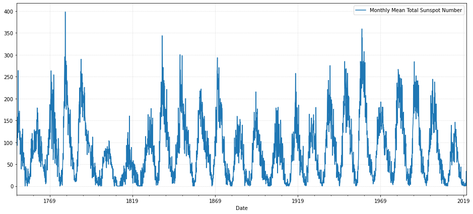

```python
df2.plot(y='Monthly Mean Total Sunspot Number',grid=True, figsize=(16,7))
plt.grid(color='lightgrey', linestyle='--', linewidth=.5)
```

As it can be appreciated in the figure, the sunspot activity presents *seasonality*, which is a typical characteristic of many time series consisting on patterns that repeat over time. More specifically, this pattern coincides approximately with the 11-year solar cycle. However, the repeating pattern is not regular over the cycles, where some of them present much higher peaks than others. If two consecutive cycles are plotted jointly over the 11 years that they last, this seasonality can be further appreciated.

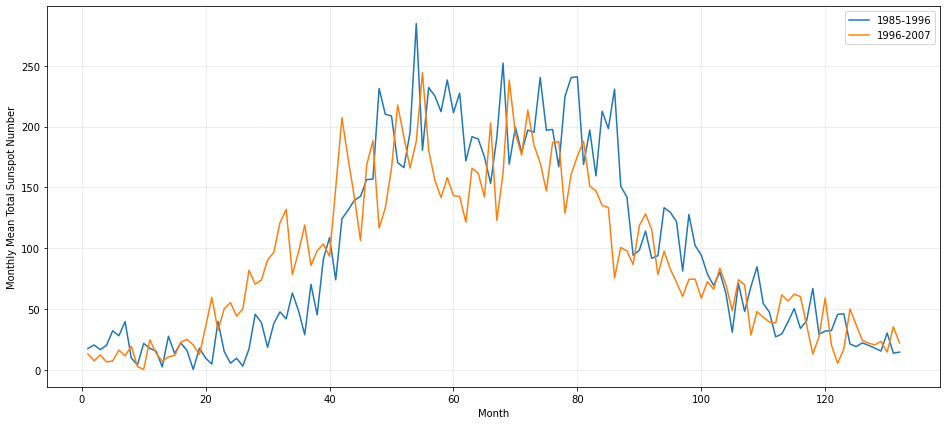

```python
df_11_1985 = df[(df.Date.dt.year >= 1985) & (df.Date.dt.year<1996)]
df_11_1996 = df[(df.Date.dt.year >= 1996) & (df.Date.dt.year<2007)]

x = np.arange(1, len(df_11_1996['Date'])+1)

plt.figure(figsize=(16,7))
plt.plot(x, df_11_1985['Monthly Mean Total Sunspot Number'], label='1985-1996')
plt.plot(x, df_11_1996['Monthly Mean Total Sunspot Number'], label='1996-2007')
plt.legend()
plt.grid(color='lightgrey', linestyle='--', linewidth=.5)
plt.xlabel('Month')
plt.ylabel('Monthly Mean Total Sunspot Number')
plt.show()
```

Another pattern typically found in time series data is the *trend*, which is observed when the values have a tendency to decrease or increase over time. The sunspot data seems not to follow a general slope conforming a trend, since the sun's activity does not increase or decrease above all across the years (i.e. the new cycles do not increase or decrease but they are constant over a range of values).

Stationary time series are those that its statistical properties, mean and variance, do not change over time. The stationarity of a time series is an important aspect to take into account when analyzing them, specially when carrying out statistical analysis, the majority of them working on the assumption that the data follows this characteristic.

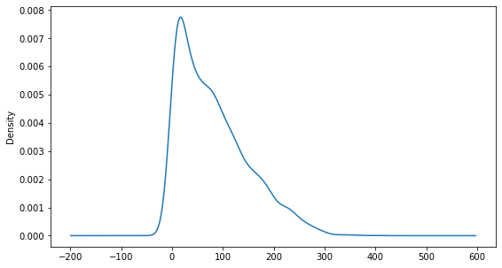

```python
plt.figure(figsize=(9,5))
df['Monthly Mean Total Sunspot Number'].plot(kind='density')
```

```python
from statsmodels.tsa.stattools import adfuller
X = df['Monthly Mean Total Sunspot Number'].values
result = adfuller(X)
print('ADF Statistic: %f' % result[0])
print('p-value: %f6' % result[1])
```

```
ADF Statistic: -10.497052
p-value: 0.0000006
```

As it can be seen, the *p-value* of the test is far lower than $0.05$, therefore rejecting the null hypothesis and concluding that the sunspot data is stationary. That is can be considered an important fact because stationary time series are easier to model and analyse statistically ---In the cases that time series are non-stationary, techniques for converting it to stationary are usually applied, such as differencing and log transform.---.

There are several statistical techniques to analyze and forecast time series, such as Moving Averages, Exponential Smoothing and Autoregressive Models. However, Machine Learning Models are frequently used in time series for modeling and predicting, achieving considerably good results in many fields (economics, weather forecasting, medical signals, etc.).

## Model Training

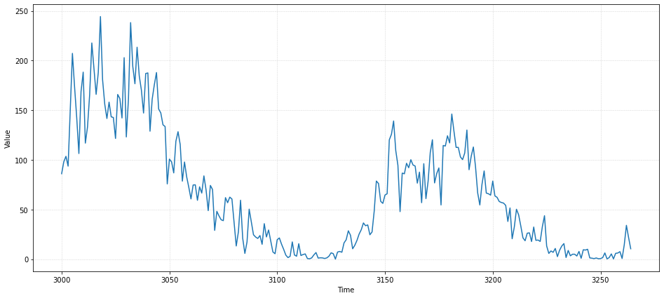

```python
plt.figure(figsize=(16,7))
plot_series(time_valid, x_valid)
plt.grid(color='lightgrey', linestyle='--', linewidth=.5)
```

Three models are going to be trained on the sunspot data: a dense neural network (DNN), a Recurrent Neural Network (RNN) and a LSTM Neural Network. Tensforflow `tf` and Keras are going to be used to implement them. The architecture between models will be intended to be as similar as possible in such a way that that comparisons between models will be based as most as possible on the type of network used. To do so, the architectures will have a similar number of layers, the same metrics and optimization algorithm, as well as they will be trained with the same number of epochs (more on that later).

The models will be fed with this prepared windowed data and will learn how to predict the next value given a sequence of $n$ window size. Therefore, the sunspot dataset saw previously has to be transformed into a windowed dataset compatible with the tensoflow models. The `windowed_dataset()` function is defined to make these transformations.

```python
def windowed_dataset(series, window_size, batch_size, shuffle_buffer):
    dataset = tf.data.Dataset.from_tensor_slices(series)
    dataset = dataset.window(window_size + 1, shift=1, drop_remainder=True)
    dataset = dataset.flat_map(lambda window: window.batch(window_size + 1))
    dataset = dataset.shuffle(shuffle_buffer).map(lambda window: (window[:-1], window[-1]))
    dataset = dataset.batch(batch_size).prefetch(1)
    return dataset
# The output shape of one elemnt in dataset object is (32, 30) and (32,)
```

```python
ds = tf.data.Dataset.range(7).window(3, 2, 1, True)
for window in ds:
    print(list(window.as_numpy_iterator()))
print()

ds = tf.data.Dataset.range(7).window(3, 1, 2, True)
for window in ds:
    print(list(window.as_numpy_iterator()))
```

```
[0, 1, 2]
[2, 3, 4]
[4, 5, 6]

[0, 2, 4]
[1, 3, 5]
[2, 4, 6]
```

The second line using `flat_map()` ensures that the order on the dataset stays the same. Then in the third line the split separating features from labels is generated with `map()`, where every sequence is split to all its values (`[:-1]`) but the last one (`[-1:]`), which will be the label.

```python
ds = tf.data.Dataset.range(10)
ds = ds.window(5, shift=1, drop_remainder=True) # dataset consists of 6 elements in which each one is
# composed of 5 scalar tensors of shape=()
ds = ds.flat_map(lambda window: window.batch(5)) # dataset consist of 6 elements in which each
# one is composed of 1d tensors of shape=(,5)
for window in ds:
    print(window.numpy())
```

```
[0 1 2 3 4]
[1 2 3 4 5]
[2 3 4 5 6]
[3 4 5 6 7]
[4 5 6 7 8]
[5 6 7 8 9]
```

Up to this point the sequences are prepared to be inputed to the tensorflow models, however the last two lines are recommended for better performance. Since many times the order of things can impact the training of the models (sequence bias --- The favouring of the items due to their position in a sequence, where the ones at the beginning and at the end have a tendency of being selected more than those in the middle---), the order of the sequences is randomly shuffled with the `shuffle()` method ---The buffer takes $n$ elements from the dataset and it is used for large datasets that do not fit in memory, but also is used to speed the random shuffle---. Next, the sequences are wrapped into batches of `batch_size` in order make the training of the models to take several sequences at a time instead of only one, thereby speeding up performance. Finally, the `prefetch()` method makes the batches of data ready to use while the current one is being processed.

```python
ds = tf.data.Dataset.range(10)
ds = ds.window(5, shift=1, drop_remainder=True)
ds = ds.flat_map(lambda window: window.batch(5))
ds = ds.map(lambda window: (window[:-1], window[-1:]))
ds = ds.shuffle(buffer_size=10)
for x,y in ds:
    print(x.numpy(), y.numpy())
```

```
[1 2 3 4] [5]
[3 4 5 6] [7]
[0 1 2 3] [4]
[4 5 6 7] [8]
[2 3 4 5] [6]
[5 6 7 8] [9]
```

```python
dataset = tf.data.Dataset.range(10)
dataset = dataset.window(5, shift=1, drop_remainder=True)
dataset = dataset.flat_map(lambda window: window.batch(5))
dataset = dataset.map(lambda window: (window[:-1], window[-1:]))
dataset = dataset.shuffle(buffer_size=10)
dataset = dataset.batch(2).prefetch(1)
for x,y in dataset:
    print("x = ", x.numpy())
    print('x shape: ', x.numpy().shape)
    print("y = ", y.numpy())
    print("y shape:", y.numpy().shape)
```

```
x =  [[4 5 6 7]
 [2 3 4 5]]
x shape:  (2, 4)
y =  [[8]
 [6]]
y shape: (2, 1)
x =  [[5 6 7 8]
 [3 4 5 6]]
x shape:  (2, 4)
y =  [[9]
 [7]]
y shape: (2, 1)
x =  [[1 2 3 4]
 [0 1 2 3]]
x shape:  (2, 4)
y =  [[5]
 [4]]
y shape: (2, 1)
```

### Splitting the data and applying window function

Once the window function is implemented, it can be applied upon the sunspot dataset. Firstly we take X and Y from the dataset, corresponding time (month number starting from Jan 1749) and the sunspot activity. Then X and Y are split into training and validation set, being the former the first 3000 months and the later the 264 most recent reminding months (22 years) (the validation has been visualized previously). Next the `windowed_dataset()` function is called specifying windows of size 60 and `batch` and `buffer` size. The resulting dataset will be the input of our neural network models.

```python
time=df['Index'].values
series=df['Monthly Mean Total Sunspot Number'].values

split_time = 3000
time_train = time[:split_time]
x_train = series[:split_time]
time_valid = time[split_time:]
x_valid = series[split_time:]

window_size = 60
batch_size = 32
shuffle_buffer_size = 1000

dataset = windowed_dataset(x_train, window_size, batch_size, shuffle_buffer_size)
```

### DNN

The first architecture implemented is a dense neural network conformed of two hidden layers with `relu` activation function ($f(x)=max(0,x)$), the first one with 20 neurons and the second one with 10. The output layer is a single neuron returning a final unique prediction for each windowed input. The metric used to assess how far the predictions are from the true train labels is the Mean Square Error, which penalizes more the errors (1). The loss will be used to calculate the gradient, which will be passed to the Stochastic Gradient Descend algorithm (`SGD`), to optimize iteratively the weights and biases of the network ---Instead of taking steps by computing the gradient of the loss function $J(x)$ generated by summing all the loss functions like Gradient Descent does, SGD takes steps by computing the gradient of the loss of only one randomly sampled example, thus avoiding getting stuck and converging faster.---. $$MSE = \frac{1}{n}\sum_{i=1}^n (y_i - \hat{y}_i)^2$$

Once the model is compiled, we train it calling `model_fit()` using 100 epochs, which denotes the number of complete passes the model takes through the training dataset.

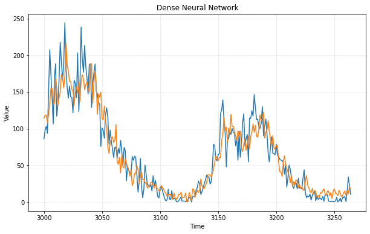

```python
tf.keras.backend.clear_session()
# Dense Neural Network
model = tf.keras.models.Sequential([
        tf.keras.layers.Dense(20, input_shape=[window_size], activation="relu"),
        tf.keras.layers.Dense(10, activation="relu"),
        tf.keras.layers.Dense(1)
])

model.compile(loss="mse", optimizer=SGD(lr=1e-8, momentum=0.9))
model.fit(dataset,epochs=100,verbose=0)

forecast = []
for time in range(len(series) - window_size):
    forecast.append(model.predict(series[time:time + window_size][np.newaxis]))

forecast = forecast[split_time - window_size:]
results = np.array(forecast)[:, 0, 0]
plt.figure(figsize=(10,6))
plot_series(time_valid, x_valid)
plot_series(time_valid, results)
plt.grid(color='lightgrey', linestyle='--', linewidth=.5)
plt.title("Dense Neural Network")
```

```python
tf.keras.metrics.mean_absolute_error(x_valid, results).numpy()
```

```
15.646276
```

Dense Neural Networks consider the inputs as fixed, therefore they do not handle ordered sequential data because they do not have a notion of time or sequence. Despite that, by taking a sufficient amount of training data, they can learn characteristic time series patterns that sometimes lead to good predictions.

### Recurrent Neural Network

As it saw saw in the last delivery, Recurrent Neural Networks maintain the inherent relationship in the sequence relating the computation that the neurons are doing in a particular time step from prior steps as well as the input at the current time step. RNN are implemented by using the Keras `SimpleRNN` layer, which takes as input a three dimensional tensor with shape `[batch, timesteps, feature]`. Therefore, it is necessary to expand the dimensions to 3 (at the moment batch and timesteps are only taken) by applying a lambda layer calling `expand_dims()` to every input `x`, and setting `input_shape=none` to take sequences of any length. In this way, having a window size of 30 timesteps batched up in sizes of 32, the shape will be `(32, 30, 1)`, being 1 the dimensionality of the input at each time step since we are working with univariate time series.

Once the dimensions are compatible with the RNN, the first layer will learn from the windowed sequences, passing a hidden state from one step to the other and adjusting its weights. On each step the cell will get the current input and the previous output. For this layer,`40` units are specified, being a tunable parameter the means the dimension of the inner cells of a recurrent neuron. Besides, `return_sequences` is set to true in order to return a sequence of outputs instead of a single output, thereby this sequence can be the input of the following RNN layer (i.e. it serves to stack one RNN on top of another).

Since the default activation function is the hyperbolic tangent ($f(x) = \frac{e^x – e^{-x}}{e^x + e^{-x}}$), its output values range between -1 and 1. For this reason the output Danse layer will return values conditioned by the previous RNN layers. Due to the fact that the outputs of the sunspot dataset range from 0 to 400, it is recommended to help the process of learning by scaling up those final outputs of the Dense layer. To do so, another lambda layer is added scaling the final outputs by a factor of 100.

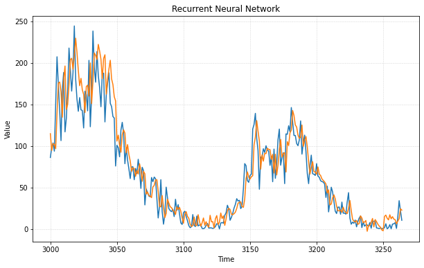

```python
# Recurrent Neural Network
model = tf.keras.models.Sequential([
  tf.keras.layers.Lambda(lambda x: tf.expand_dims(x, axis=-1), input_shape=[None]),
  tf.keras.layers.SimpleRNN(40, return_sequences=True),
  tf.keras.layers.SimpleRNN(38),
  tf.keras.layers.Dense(1),
  tf.keras.layers.Lambda(lambda x: x*100.0)
])

model.compile(loss="mse", optimizer=SGD(lr=1e-8, momentum=0.9))
model.fit(dataset,epochs=100,verbose=0)

forecast = []
for time in range(len(series) - window_size):
    forecast.append(model.predict(series[time:time + window_size][np.newaxis]))

forecast = forecast[split_time - window_size:]
results = np.array(forecast)[:, 0, 0]
plt.figure(figsize=(10,6))
plot_series(time_valid, x_valid)
plot_series(time_valid, results)
plt.grid(color='lightgrey', linestyle='--', linewidth=.5)
plt.title("Recurrent Neural Network")
```

```python
tf.keras.metrics.mean_absolute_error(x_valid, results).numpy()
```

```
15.15611
```

### LSTM

Long-Short Term Memory Networks are similar to RNN, but they contain different interacting layers called *gates* that control which information passes through the network and which not. Moreover, a cell state goes through the sequence as a flow of information, being effectively and selectively modified in each time step by the gates, consequently having longer memory. That is, the data from earlier timesteps in the window can have a greater impact on the overall prediction than in the case of RNN. Due to this characteristics LSTMs are considered better than RNNs when predicting time series.

A LSTM neural network using two Keras `LSTM` layers is implemented in the same way than the previous RNN, since they need the same input dimensions and use the same activation functions.

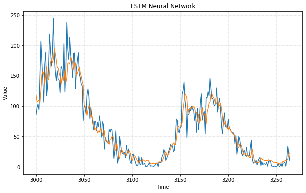

```python
# LSTM Network
model = tf.keras.models.Sequential([
  tf.keras.layers.Lambda(lambda x: tf.expand_dims(x, axis=-1), input_shape=[None]),
  tf.keras.layers.LSTM(38, return_sequences=True),
  tf.keras.layers.LSTM(38),
  tf.keras.layers.Dense(1),
  tf.keras.layers.Lambda(lambda x: x*400.0)
])

model.compile(loss="mse", optimizer=SGD(lr=1e-8, momentum=0.9))
model.fit(dataset,epochs=100,verbose=0)

forecast = []
for time in range(len(series) - window_size):
    forecast.append(model.predict(series[time:time + window_size][np.newaxis]))

forecast = forecast[split_time - window_size:]
results = np.array(forecast)[:, 0, 0]
plt.figure(figsize=(10,6))
plot_series(time_valid, x_valid)
plot_series(time_valid, results)
plt.grid(color='lightgrey', linestyle='--', linewidth=.5)
plt.title("LSTM Neural Network")
```

```python
tf.keras.metrics.mean_absolute_error(x_valid, results).numpy()
```

```
13.587717
```

### Comparisons

In order to obtain the results of the predictions, we iterate over all possible windows, starting from time `0` to the time of the last possible window (`len(Y)-window_size`) and for each window `model_predict()` is called to make the prediction of the next value (`np.newaxis` is called to expand the dimensionality to 2 for future compatibilities). All the predicted values are stored into a list, which is sliced to obtain the values of the validation set. Finally all array predictions are stored together in a 1 dimensional array.

With the results of each model (and trying different window sizes on each one), the final performance of the model for predicting the validation set is calculated by using the Mean Absolute Error between real and predicted values ($\frac{1}{n}\sum_{i=1}^n |y_i - \hat{y}_i|$).

```python
d={'Window_size':[12, 30, 60, 120, 132],
'DNN':[13.9007, 14.5918, 15.6462, 17.0593, 17.3368],
'RNN':[15.2418, 15.3188, 15.1561, 15.0249, 17.6033],
'LSTM':[14.0384, 15.8590, 13.5877, 14.3933, 17.6034]}
summary=pd.DataFrame(d)
summary
```

|  | Window_size | DNN | RNN | LSTM |
| --- | --- | --- | --- | --- |
| 0 | 12 | 13.9007 | 15.2418 | 14.0384 |
| 1 | 30 | 14.5918 | 15.3188 | 15.8590 |
| 2 | 60 | 15.6462 | 15.1561 | 13.5877 |
| 3 | 120 | 17.0593 | 15.0249 | 14.3933 |
| 4 | 132 | 17.3368 | 17.6033 | 17.6034 |

Table contains the results for the different models with different window sizes. It can be noticed that Dense Neural Networks, despite not recognising the notion of sequence and considering the data as fixed over time, perform surprisingly well even with a simple model like the one implemented. The underlying idea of these results is that this type of networks discover characteristic patterns that help them make good predictions. Besides, it is also noticed that the performance results are better with small window sizes, and it decays as they get bigger. This may stem from the fact that DNN do not learn relations and dependencies over time periods, thus increasing the size only increases the fixed input data without considering the possible relations that can be detected over longer time periods.

If the best predictions obtained by the LSTM model are plotted together with the real values of the validation set, it can be appreciated that the forecast approaches significantly well the sunspot activity, capturing the increases and decreases of the activity. Some peaks and noise are not captured by the model, but this is expected because we want models that generalize well on unseen data, not overffiting and learning the noise of the training data.

## Conclusions

Different neural network architectures were tried for predicting time series data about sunspot activity. Initially, some exploration of the characteristics of the series have been undertaken. Then, we went through the process of preparing sequence data in order to make it compatible for deep learning models, and realized how the window size is a key factor on the final performance of those models.

The model that gave the best predictions was a Long-Short Term Memory neural network conformed of three layers, however a simple Dense Neural Network surprisingly generated good predictions, approaching those of the LSTM and overcoming Recurrent Neural Networks.

Further architectures could have been tried, such as increasing the number of layers and units in each one, trying different optimization algorithms (like RMSProp and Adam), adjusting the learning rate, making models combining LSTM layers with DNN layers, or even extracting characteristic features using Convolutional Neural Networks. Nonetheless, simple models oftentimes get good enough results, even surpassing more complex ones like we saw in DNN against RNN.